[figure not shown]

Control Module I/O Signal

VEHICLE DYNAMICS CONTROL (VDC) (DIAGNOSTICS)

5. Control Module I/O Signal

A: ELECTRICAL SPECIFICATION

NOTE:

• Terminal numbers in VDCCM&H/U connector (on the control module side) are shown in the figure.

• When the connector is removed from the VDCCM&H/U, the brake warning light (EBD warning light), ABS

warning light, VDC warning light & VDC indicator light, VDC OFF indicator light, and the hill start assist warn-

ing light illuminate.

Contents

Terminal No.

(+) — (–)

Input/Output signal

Measured value and measuring conditions

Power supply 31 — 38 10 — 15 V when the ignition switch is ON.

ABS wheel

speed sensor

Front LH wheel

Power supply 12 — 38 0 — 18 V

Signal 13 7 — 14 mA: Rectangle waveform

Front RH wheel

Power supply 3 — 38 0 — 18 V

Signal 2 7 — 14 mA: Rectangle waveform

Rear LH wheel

Power supply 5 — 38 0 — 18 V

Signal 6 7 — 14 mA: Rectangle waveform

Rear RH wheel

Power supply 10 — 38 0 — 18 V

Signal 9 7 — 14 mA: Rectangle waveform

CAN communication line (H) 36 2.75 — 4.5 V pulse signal

CAN communication line (L) 35 0.5 — 2.25 V pulse signal

Valve relay power supply 1 — 38 10 — 15 V when the ignition switch is ON.

Motor relay power supply 26 — 38 10 — 15 V when the ignition switch is ON.

Stop light switch 27 — 38

1.5 V or less when the stop light is OFF;

otherwise, 10 — 15 V when the stop light is ON.

Vehicle speed output signal 30 0 ←→ 12 V pulse

VDC OFF switch 21 — 38

1 Ω or less when the OFF switch is “ON”;

1 MΩ or more when the switch is “OFF”.

Ground 38 —

B310

3

9

7

6

4

5

8

1

25

38

24

23

17

16

15

26

14

10

12

13

11

VDC01159

TO

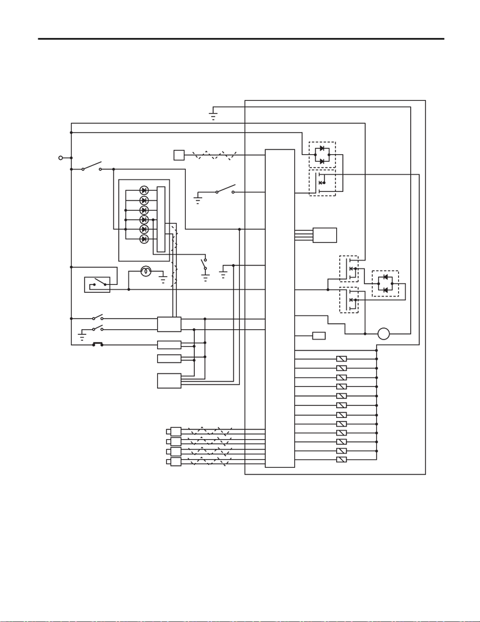

Control Module I/O Signal

VEHICLE DYNAMICS CONTROL (VDC) (DIAGNOSTICS)

B: WIRING DIAGRAM

VDC01282

(7)

(6)

(5)

(11)

M

(12)

(13)

(20)

(2)

(22)

(4)

(42)

(29)

(36)

(14)

(8)

(9)

(10)

(15)

(16)

(17)

(18)

(1)

(21)

(33)

(32)

(31)

(43)

(41)

(44)

(30)

(37)

(38)

(39)

(19)

(35)

(40)

(26)

(25)

(27)

(28)

(34)

(24)

(23)

[figure not shown]

Control Module I/O Signal

VEHICLE DYNAMICS CONTROL (VDC) (DIAGNOSTICS)

(1) Battery (16) Primary cut solenoid valve (31) Body integrated unit

(2) Ignition switch (17) Primary suction solenoid valve (32) Engine control module (ECM)

(3) VDC control module and hydraulic

control unit (VDCCM&H/U)

(18) Secondary cut solenoid valve (33) Transmission control module

(TCM) (CVT model)

Driver’s control center differential

control module (DCCD) (STI

model)

(4) VDC control module (19) Secondary suction solenoid valve (34) Steering angle sensor

(5) Valve relay (20) Data link connector (35) Pressure sensor

(6) Motor relay (21) VDC OFF switch (36) Front ABS wheel speed sensor LH

(7) Motor (22) Combination meter (37) Front ABS wheel speed sensor

RH

(8) Front inlet solenoid valve LH (23) VDC OFF indicator light (38) Rear ABS wheel speed sensor LH

(9) Front outlet solenoid valve LH (24) VDC warning light & VDC indica-

tor light

(39) Rear ABS wheel speed sensor

RH

(10) Front inlet solenoid valve RH (25) ABS warning light (40) Yaw rate & G sensor

(11) Front outlet solenoid valve RH (26) Brake warning light (EBD warning

light)

(41) Parking brake switch

(12) Rear inlet solenoid valve LH (27) Hill start assist warning light (42) Brake fluid level switch

(13) Rear outlet solenoid valve LH (28) VDC traction mode indicator light (43) Back-up light switch (MT model)

(14) Rear inlet solenoid valve RH (29) Stop light switch (44) Clutch switch (MT model)

(15) Rear outlet solenoid valve RH (30) Stop light